## Monty Hall Simulation

#### By Brian Hudnall

##### Executive Summary: The Monty Hall problem is a brain teaser, in the form of a probability puzzle (Gruber, Krauss and others), loosely based on the American television game show Let’s Make a Deal. You’re given the choice of three doors: Behind one door is a car; behind the others, goats. You pick a door, say No. 1, and the host, who knows what’s behind the doors, opens another door, say No. 3, which has a goat. He then says to you, “Do you want to pick door No. 2?” Is it to your advantage to switch your choice? Monty_Hall_problem

##### Results: The simulation proves that it’s smarter to switch doors. This was previously proven by Vos Savant. Whose response was that the contestant should switch to the other door.

#### Function creation:

Load the necessary packages used in analysis.

```r
set.seed(42)
library(dplyr)
library(ggplot2)
```

Create a function that simulates the initial choices, which door the car is behind, and if the contestant either switches or stays.

```r
sim_n <- 1000

sim_initial_choice <- function(n = sim_n) {

        door_choice <- runif(n)
        door_choice <- ifelse(door_choice <= 1/3, 1
               , ifelse(door_choice <= 2/3, 2, 3))
        car <- runif(n)
        car <- ifelse(car <= 1/3, 1
                      , ifelse(car <= 2/3, 2, 3))
        final_choice <- runif(n)
        final_choice <- ifelse(final_choice <= 1/2, 'switch', 'stay')
        df <- data.frame(door_choice, car, final_choice)
}
```

The next function will determine if the contestant had success or failure depending on if they switched or stayed and the location of the car.

```r
## This simulates the choice a contestant would make
## assuming the car is behind door #1 and they choose to make a switch
sim_result <- function(df = sim_df) {

        df[,4] <- NA;
        names(df)[4] <- "result"
        for(i in 1:nrow(df)) {
                if(df[i,"final_choice"] == "stay") {
                        if(df[i,"door_choice"] == df[i, "car"]) {
                                df[i, "result"] <- 1
                        }
                        else {
                                df[i, "result"] <- 0
                        }
                }
                else {
                        if(df[i, "door_choice"] != df[i, "car"]) {
                                df[i, "result"] <- 1
                        }
                        else {
                                df[i, "result"] <- 0
                        }

                }
        }
        df
}
```

This next function will calculate the mean and variance of the results.

```r
## summarise the results and return a Data Frame
## also add a column for the probability of results
## given a car or a goat output
result_summary <- function(df) {

        df <- df %>%
                group_by(final_choice) %>%
                summarise(probability = mean(result), variance = var(result))

}
```

This last function will plot the results.

```r
## Plot the initial results
plot_summary <- function(df) {

        ggplot(df, aes(x = final_choice, y = probability)) +
                geom_bar(stat = "identity")

}
```

#### Run simulation:

We now utilize these functions to plot the simulation and calculate the probability and variance of either staying or switching doors.

```r
## First we create the data set that contains random contestant selections, car door assignment, and stay or switch
df <- sim_initial_choice(sim_n)
summary(df)
```

```
##   door_choice         car        final_choice
##  Min.   :1.000   Min.   :1.000   stay  :506
##  1st Qu.:1.000   1st Qu.:1.000   switch:494
##  Median :2.000   Median :2.000
##  Mean   :1.979   Mean   :1.999
##  3rd Qu.:3.000   3rd Qu.:3.000
##  Max.   :3.000   Max.   :3.000
```

```r
head(df)
```

```
##   door_choice car final_choice
## 1           3   1       switch
## 2           1   3         stay
## 3           3   2         stay
## 4           2   2         stay
## 5           2   1         stay
## 6           3   2         stay
```

```r
## Run the sum_result function to see what the results are
df <- sim_result(df)
summary(df)
```

```
##   door_choice         car        final_choice     result
##  Min.   :1.000   Min.   :1.000   stay  :506   Min.   :0.000
##  1st Qu.:1.000   1st Qu.:1.000   switch:494   1st Qu.:0.000
##  Median :2.000   Median :2.000                Median :0.000
##  Mean   :1.979   Mean   :1.999                Mean   :0.498
##  3rd Qu.:3.000   3rd Qu.:3.000                3rd Qu.:1.000
##  Max.   :3.000   Max.   :3.000                Max.   :1.000
```

```r
head(df)
```

```
##   door_choice car final_choice result
## 1           3   1       switch      1
## 2           1   3         stay      0
## 3           3   2         stay      0
## 4           2   2         stay      1
## 5           2   1         stay      0
## 6           3   2         stay      0
```

```r
## Now calculate the probability and the variance
df <- result_summary(df)
summary(df)
```

```
##  final_choice  probability       variance
##  stay  :1     Min.   :0.332   Min.   :0.2222
##  switch:1     1st Qu.:0.416   1st Qu.:0.2222
##               Median :0.500   Median :0.2222
##               Mean   :0.500   Mean   :0.2222
##               3rd Qu.:0.584   3rd Qu.:0.2222
##               Max.   :0.668   Max.   :0.2222
```

```r
head(df)
```

```
## Source: local data frame [2 x 3]
##
##   final_choice probability  variance
## 1         stay   0.3320158 0.2222205
## 2       switch   0.6680162 0.2222204
```

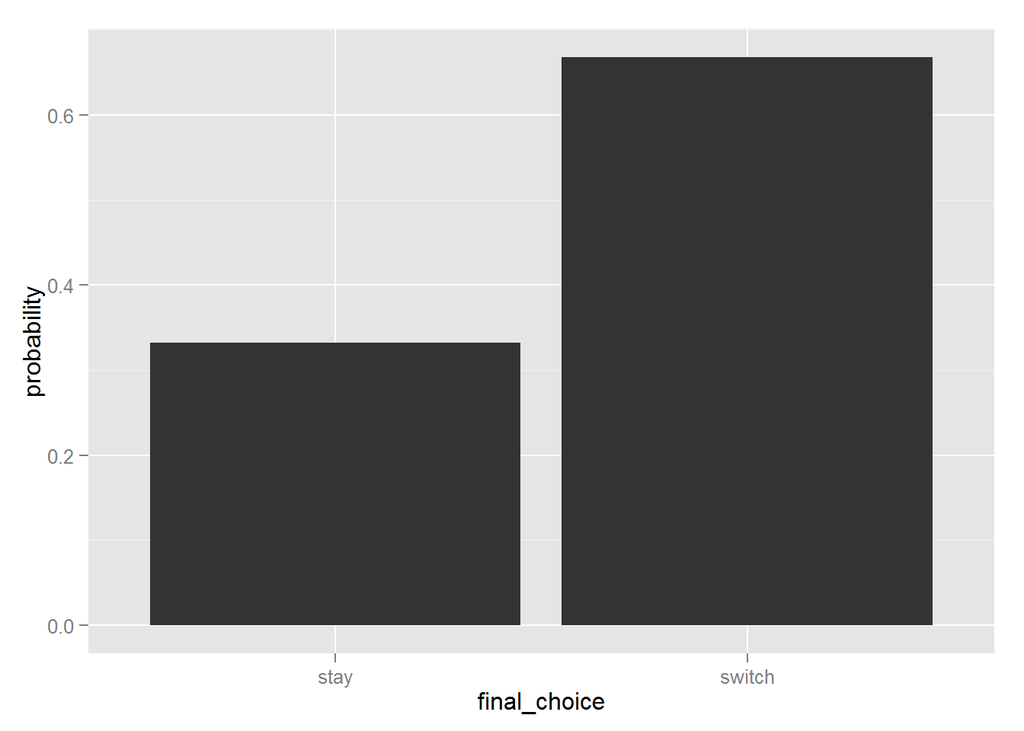

```r
## Plot the results
plot_summary(df)
```